# CENG 4515 DATA SCIENCE AND ANALYTICS-FINAL PROJECT

İrem Uslu-Hatice Özgül Bilici

2023-01-06

This data set contains records related to red and white variants of the Portuguese Vinho Verde wine. It contains information from 1599 red wine samples and 4898 white wine samples.There are also 13 attributes.The description of each attirbute is shown in the table below.

https://www.kaggle.com/datasets/ruthgn/wine-quality-data-set-red-white-wine

## Dataset Information

| Column | Description |
| --- | --- |
| Wine Type | Types of wine. White or Red? Response variable. |
| Fixed Acidity | Many acids present in wine are either fixed or nonvolatile, meaning they do not evaporate easily. |
| Volatile Acidity | High levels of acetic acid in wine can cause it to taste vinegary and unpleasant. |
| Citric Acid | Citric acid, when present in small amounts, can contribute a sense of freshness and enhance the flavor of wines. |
| Residual Sugar | The amount of sugar remaining after fermentation stops, it’s rare to find wines with less than 1 gram/liter and wines with greater than 45 grams/liter are considered sweet |
| Chlorides | The amount of salt in the wine. |
| Free SulfurDioxide | Sulfur dioxide (SO2) exists in a state of equilibrium between its molecular form (as a dissolved gas) and the bisulfite ion. It helps prevent the growth of microorganisms and the oxidation of wine. |
| Total SulfurDioxide | Sulfur dioxide (SO2) exists in both free and bound forms. When present in low concentrations, it is generally not noticeable in the aroma or flavor of wine. However, if the concentration of free SO2 e… |
| Density | The density of a wine is similar to that of water and is influenced by its alcohol and sugar content. |
| pH | The pH scale is used to measure the acidity or basicity of a wine, with 0 being very acidic and 14 being very basic. Most wines fall within the range of 3-4 on the pH scale. |
| Sulphates | Potassium metabisulfite is a wine additive that can increase the levels of sulfur dioxide gas (SO2) in the wine. SO2 acts as both an antimicrobial and an antioxidant. |
| Alcohol | The percent alcohol content of the wine. |
| Quality | Quality of wines from 3 to 9 |

## Importing libraries

```r
  library(ggplot2)
  library(tidyverse)
  library(dplyr)
  library(plyr)
  library(MASS)
  library(caret)
  library(corrplot)
  library(ROCR)
  library(Rcpp)
  library(gmodels)
  library(pROC)
  library(InformationValue)
  library(factoextra)
  library(car)
  library(ROSE)
  library(rattle)
  library(RColorBrewer)
  library(rpart.plot)
  library(Amelia)
  library(e1071)
  library(caTools)
  library(fpc)
  library(dbscan)
  library(missForest)
  library(mice)
  library(smotefamily)
```

## 1-) Description of Data

```r
setwd("C:/Users/Mary/Desktop/")
wineQuality <- read.csv("winequality.csv" , header = TRUE , sep = ",")

str(wineQuality)
```

```
## 'data.frame':    6497 obs. of  13 variables:
##  $ type                : chr  "white" "white" "white" "white" ...
##  $ fixed.acidity       : num  7 6.3 8.1 7.2 7.2 8.1 6.2 7 6.3 8.1 ...
##  $ volatile.acidity    : num  0.27 0.3 0.28 0.23 0.23 0.28 0.32 0.27 0.3 0.22 ...
##  $ citric.acid         : num  0.36 0.34 0.4 0.32 0.32 0.4 0.16 0.36 0.34 0.43 ...
##  $ residual.sugar      : num  20.7 1.6 6.9 8.5 8.5 6.9 7 20.7 1.6 1.5 ...
##  $ chlorides           : num  0.045 0.049 0.05 0.058 0.058 0.05 0.045 0.045 0.049 0.044 ...
##  $ free.sulfur.dioxide : num  45 14 30 47 47 30 30 45 14 28 ...
##  $ total.sulfur.dioxide: num  170 132 97 186 186 97 136 170 132 129 ...
##  $ density             : num  1.001 0.994 0.995 0.996 0.996 ...
##  $ pH                  : num  3 3.3 3.26 3.19 3.19 3.26 3.18 3 3.3 3.22 ...
##  $ sulphates           : num  0.45 0.49 0.44 0.4 0.4 0.44 0.47 0.45 0.49 0.45 ...
##  $ alcohol             : num  8.8 9.5 10.1 9.9 9.9 10.1 9.6 8.8 9.5 11 ...
##  $ quality             : int  6 6 6 6 6 6 6 6 6 6 ...
```

## 2-) Exploratory Data Analysis

```r
summary(wineQuality)
```

```
##      type           fixed.acidity    volatile.acidity  citric.acid
##  Length:6497        Min.   : 3.800   Min.   :0.0800   Min.   :0.0000
##  Class :character   1st Qu.: 6.400   1st Qu.:0.2300   1st Qu.:0.2500
##  Mode  :character   Median : 7.000   Median :0.2900   Median :0.3100
##                     Mean   : 7.217   Mean   :0.3397   Mean   :0.3187
##                     3rd Qu.: 7.700   3rd Qu.:0.4000   3rd Qu.:0.3900
##                     Max.   :15.900   Max.   :1.5800   Max.   :1.6600
##                     NA's   :10       NA's   :8        NA's   :3
##  residual.sugar     chlorides       free.sulfur.dioxide total.sulfur.dioxide
##  Min.   : 0.600   Min.   :0.00900   Min.   :  1.00      Min.   :  6.0
##  1st Qu.: 1.800   1st Qu.:0.03800   1st Qu.: 17.00      1st Qu.: 77.0
##  Median : 3.000   Median :0.04700   Median : 29.00      Median :118.0
##  Mean   : 5.444   Mean   :0.05604   Mean   : 30.53      Mean   :115.7
##  3rd Qu.: 8.100   3rd Qu.:0.06500   3rd Qu.: 41.00      3rd Qu.:156.0
##  Max.   :65.800   Max.   :0.61100   Max.   :289.00      Max.   :440.0
##  NA's   :2        NA's   :2
##     density             pH          sulphates         alcohol
##  Min.   :0.9871   Min.   :2.720   Min.   :0.2200   Min.   : 8.00
##  1st Qu.:0.9923   1st Qu.:3.110   1st Qu.:0.4300   1st Qu.: 9.50
##  Median :0.9949   Median :3.210   Median :0.5100   Median :10.30
##  Mean   :0.9947   Mean   :3.218   Mean   :0.5312   Mean   :10.49
##  3rd Qu.:0.9970   3rd Qu.:3.320   3rd Qu.:0.6000   3rd Qu.:11.30
##  Max.   :1.0390   Max.   :4.010   Max.   :2.0000   Max.   :14.90
##                   NA's   :9       NA's   :4
##     quality
##  Min.   :3.000
##  1st Qu.:5.000
##  Median :6.000
##  Mean   :5.818
##  3rd Qu.:6.000
##  Max.   :9.000
##
```

```r
head(wineQuality , 5)
```

```
##    type fixed.acidity volatile.acidity citric.acid residual.sugar chlorides
## 1 white           7.0             0.27        0.36           20.7     0.045
## 2 white           6.3             0.30        0.34            1.6     0.049
## 3 white           8.1             0.28        0.40            6.9     0.050
## 4 white           7.2             0.23        0.32            8.5     0.058
## 5 white           7.2             0.23        0.32            8.5     0.058
##   free.sulfur.dioxide total.sulfur.dioxide density   pH sulphates alcohol
## 1                  45                  170  1.0010 3.00      0.45     8.8
## 2                  14                  132  0.9940 3.30      0.49     9.5
## 3                  30                   97  0.9951 3.26      0.44    10.1
## 4                  47                  186  0.9956 3.19      0.40     9.9
## 5                  47                  186  0.9956 3.19      0.40     9.9
##   quality
## 1       6
## 2       6
## 3       6
## 4       6
## 5       6
```

```r
colnames(wineQuality) <- c("wine_type", "fixed_acidity",
                       "volatile_acidity", "citric_acid", "residual_sugar","chlorides", "free_sulfurDioxide","total_sulfurDioxide","density","pH","sulphates","alcohol","quality")

colnames(wineQuality)
```

```
##  [1] "wine_type"           "fixed_acidity"       "volatile_acidity"
##  [4] "citric_acid"         "residual_sugar"      "chlorides"
##  [7] "free_sulfurDioxide"  "total_sulfurDioxide" "density"
## [10] "pH"                  "sulphates"           "alcohol"
## [13] "quality"
```

```r
wineQuality <- transform(wineQuality ,
                                  wine_type = as.factor(wine_type)
                                  )

wineQuality <- transform(wineQuality ,
                         quality = as.factor(quality)
                                  )
```

The wine_type variable has been converted to the variable factor. Because, in our assignment, the answer variable is the wine type. The properties of each column were examined with the Summary function. Finally, we made the column names more understandable.

```r
  df1 <- wineQuality %>%
                          filter(wine_type=="white")%>%
                          dplyr::select(wine_type,pH)%>%
                          arrange(pH)

head(df1,6)
```

```
##   wine_type   pH
## 1     white 2.72
## 2     white 2.74
## 3     white 2.77
## 4     white 2.79
## 5     white 2.79
## 6     white 2.79
```

Sorts the ph values of the white wine types from the smallest to the largest.

```r
  df2 <- wineQuality %>%
                          filter(wine_type == "white"  & residual_sugar>20)%>%
                          dplyr::select(wine_type,alcohol)%>%
                          arrange(alcohol)
  head(df2,6)
```

```
##   wine_type alcohol
## 1     white     8.5
## 2     white     8.6
## 3     white     8.7
## 4     white     8.7
## 5     white     8.7
## 6     white     8.8
```

Lists white wines with a residual sugar value greater than 20 and the lowest alcohol content.

## 3-) Visualization Techniques

This bar plot shows how many red and white wines are in total.White wine is more numerous than red.

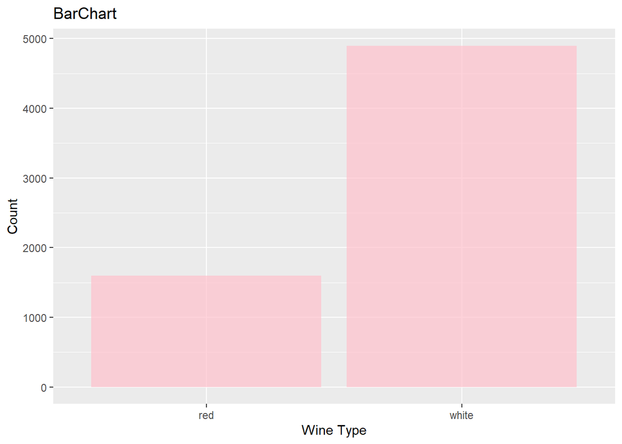

```r
  ggplot(data=wineQuality, aes(x=wine_type)) +
  geom_bar(fill="pink", alpha=0.7)+
  labs(title = "BarChart", x="Wine Type", y="Count")
```

This bar plot separates red and white wines according to the quality of the wines. We can say that the highest quality wines belong to white wine.

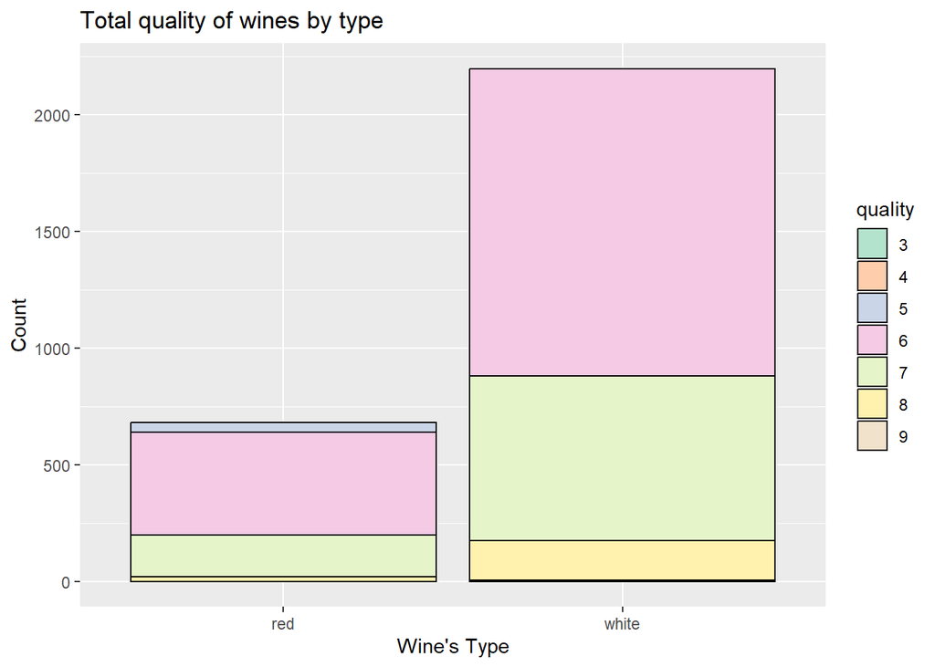

```r
  ggplot(wineQuality , mapping = aes(x = wine_type, fill = quality)) +
  geom_bar(position = "identity",color="black") +
  scale_fill_brewer(palette = "Pastel2")+
  labs( x = "Wine's Type",
        y = "Count",
        title = "Total quality of wines by type")
```

We can say that 6th quality wines contain alcohol in amounts between 9 and 13.There is little or no quality wine with a high alcohol content .

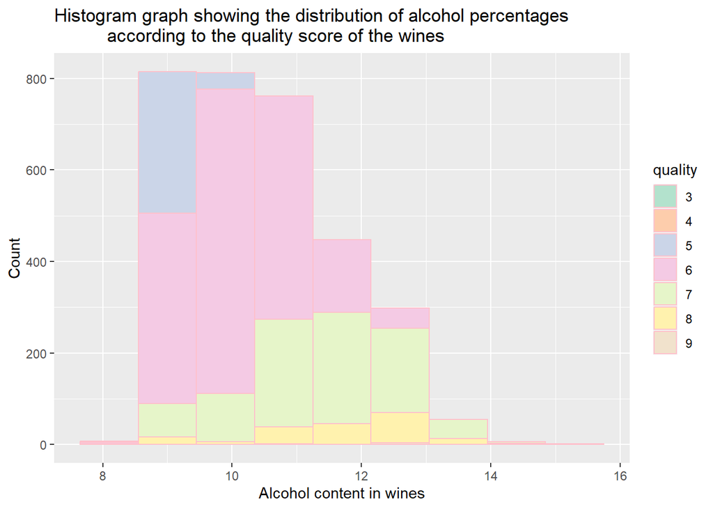

```r
  ggplot(wineQuality, aes(alcohol,fill=quality)) +
  geom_histogram(position="identity",binwidth=0.9,color="pink") +
  scale_fill_brewer(palette = "Pastel2")+
  ggtitle("Histogram graph showing the distribution of alcohol percentages
          according to the quality score of the wines") +
  xlab("Alcohol content in wines") +
  ylab("Count")
```

While 3rd and 8 quality grade wines do not contain outliers, others do. Especially 6th quality wines have too many outliers. Likewise, 4,5,7 and 9 have outliers. On average, they all contain similar residual_sugar.

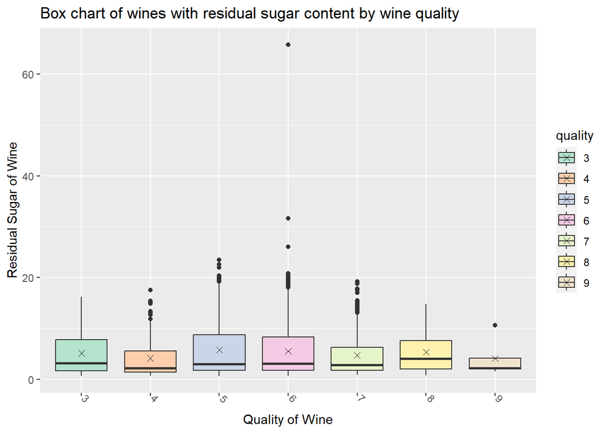

```r
  ggplot(data=wineQuality, aes(x=quality, y=residual_sugar, fill= quality)) +
  geom_boxplot() +
  labs(title = "Box chart of wines with residual sugar content by wine quality", x = "Quality of Wine", y="Residual Sugar of Wine") +
  scale_fill_brewer(palette = "Pastel2")+
  stat_summary(fun=mean, geom="point", shape=4, size=2) +
  theme(axis.text.x=element_text(angle=-45,hjust=0,vjust=0))
```

White wine contains more sulfur dioxide than red wine.The mean free sulfur dioxide ratio is also higher in white wine than in red.

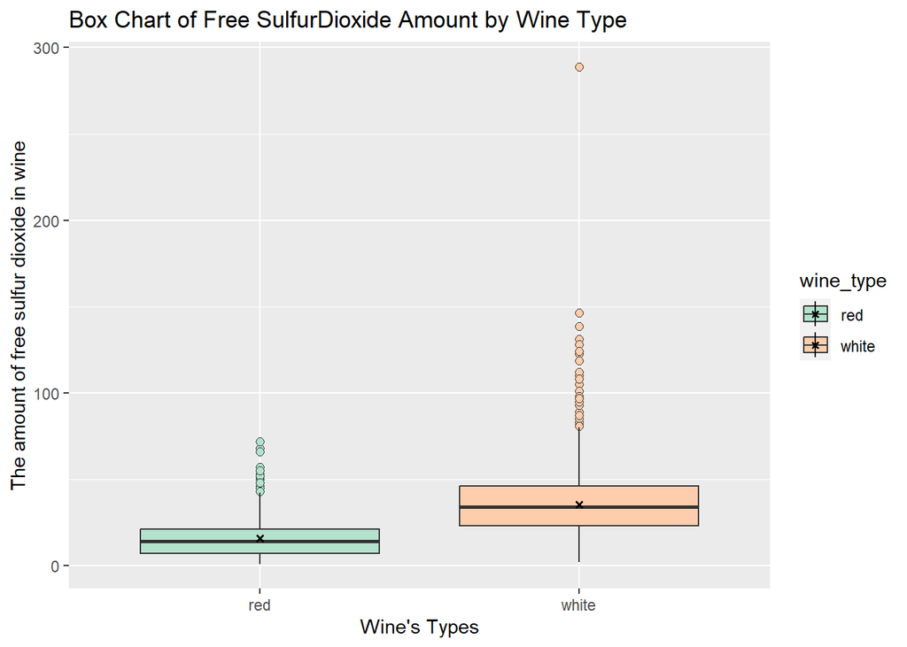

```r
  ggplot(wineQuality, mapping = aes(x = wine_type, y = free_sulfurDioxide , fill=wine_type)) +
  geom_boxplot(outlier.size = 2 ,outlier.shape = 21)+
  stat_summary(fun.y = "mean",shape=4,size=0.2)+
  labs(title = "Box Chart of Free SulfurDioxide Amount by Wine Type", x="Wine's Types", y="The amount of free sulfur dioxide in wine")+
  scale_fill_brewer(palette = "Pastel2")
```

Red wine is the most dense according to the density chart.

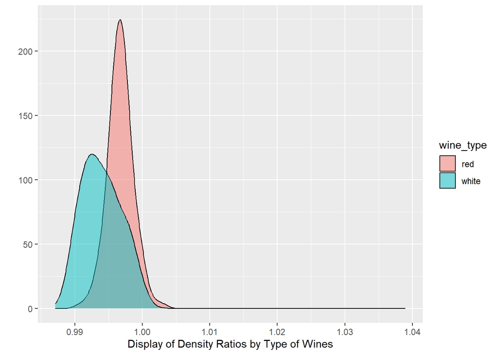

```r
qplot(fill = wine_type,
      x = density,
      data = wineQuality,
      geom = "density",
      alpha = I(0.5),
      adjust = 2
      )+ labs( x = "Display of Density Ratios by Type of Wines")
```

## Z.a-) Imbalanced Data Set

```r
table(wineQuality$wine_type)
```

```
##
##   red white
##  1599  4898
```

```r
prop.table(table(wineQuality$wine_type))
```

```
##
##       red     white
## 0.2461136 0.7538864
```

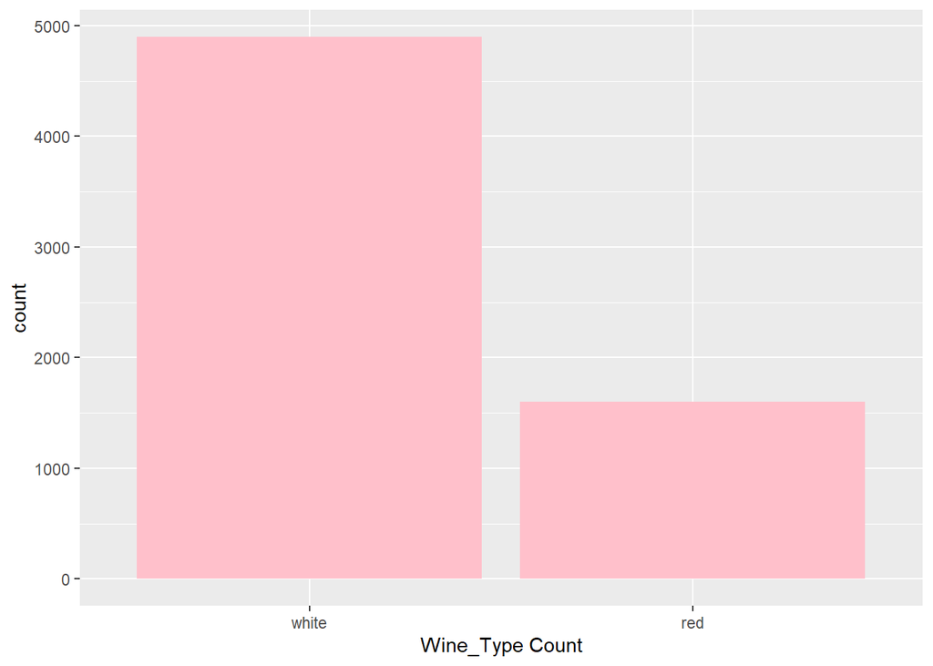

```r
ggplot(wineQuality, aes(x=reorder(wine_type, wine_type, function(x)-length(x)))) +
geom_bar(fill='pink') +  labs(x='Wine_Type Count')
```

```r
imbalanced.wineQuality <- wineQuality
missing.wineQuality <- wineQuality
```

```r
n_legit <- 4898
new_frac_legit <- 0.5
new_n_total <- n_legit/new_frac_legit

oversampling_result <- ovun.sample(wine_type ~ ., data = wineQuality, method = "over",
                                   N = new_n_total, seed = 2018)
dataset <- oversampling_result$data
row.names(dataset) <- NULL
table(dataset$wine_type)
```

```
##
## white   red
##  4870  4926
```

```r
prop.table(table(dataset$wine_type))
```

```
##
##     white       red
## 0.4971417 0.5028583
```

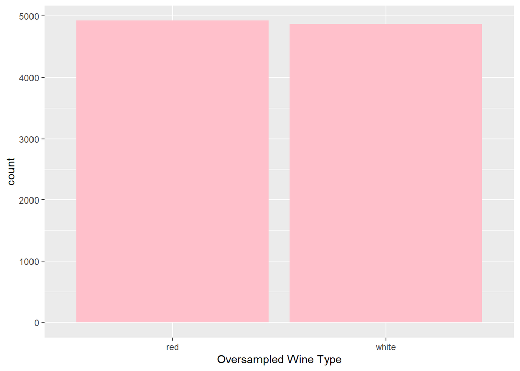

```r
ggplot(dataset, aes(x=reorder(wine_type,
                              wine_type,
                              function(x)-length(x))))+
                              geom_bar(fill='pink') +
                              labs(x='Oversampled Wine Type')
```

The wine_type column we use in our data is not balanced. There is a noticeable imbalance between them.Red is 0.24 while white wines is 0.75.When we checked our data, our values were found to be imbalanced. Therefore, we used oversampling to convert it to a balanced data set. The ratios, which were around 1500,4800 at first, approached around 4800 and 4900 after oversampling.With the bar graph,both imbalance and balance values are observed..

## 4-) Checking multicollinearity

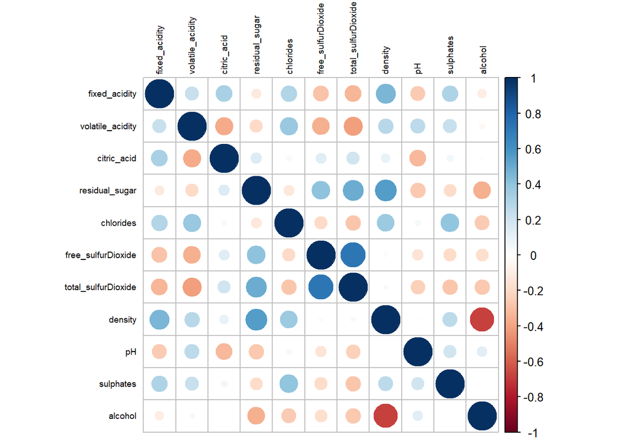

```r
wineQuality <- na.omit(wineQuality)
correlations <- cor(wineQuality[c(2:12)])
corrplot(correlations,method = "circle",tl.cex = 0.6, tl.col = "black")
```

Dark blue dots have strong positive correlations. For example, there is a strong positive relationship between free_sulfurDioxide and total_sulfurDioxide.  
Or there is a weak positive relationship between residual_sugar and free_sulfurDioxide.We can also mention that there is a strong negative relationship between density and alcohol.

## 5-) Apply PCA

```r
winePr <- prcomp(wineQuality[,c(2:11)] , scale=TRUE,center = TRUE)
summary(winePr)
```

```
## Importance of components:
##                           PC1    PC2    PC3     PC4     PC5     PC6     PC7
## Standard deviation     1.7369 1.4488 1.1958 0.98087 0.84303 0.73831 0.72209
## Proportion of Variance 0.3017 0.2099 0.1430 0.09621 0.07107 0.05451 0.05214
## Cumulative Proportion  0.3017 0.5116 0.6546 0.75079 0.82185 0.87637 0.92851
##                           PC8     PC9    PC10
## Standard deviation     0.6066 0.49954 0.31209
## Proportion of Variance 0.0368 0.02495 0.00974
## Cumulative Proportion  0.9653 0.99026 1.00000
```

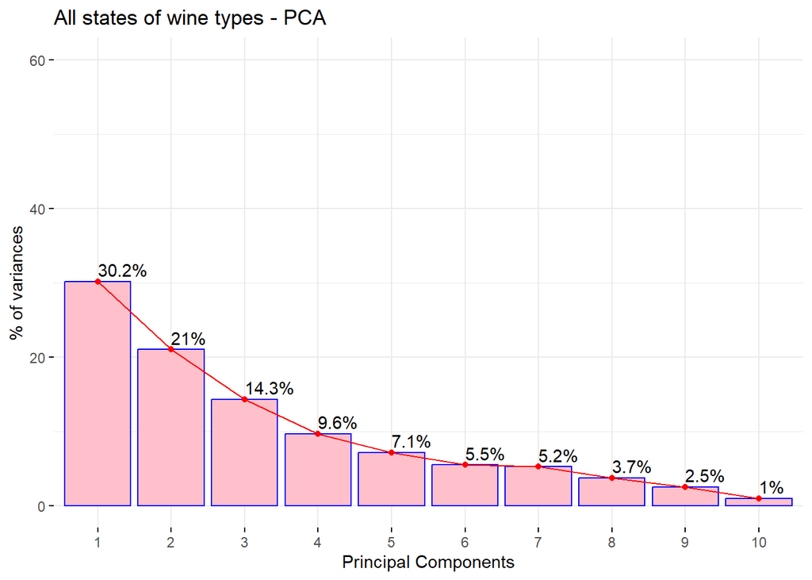

```r
fviz_eig(winePr, addlabels=TRUE, ylim=c(0,60), geom = c("bar", "line"), barfill = "pink",
         barcolor="blue",linecolor = "red", ncp=10)+
         labs(title = "All states of wine types - PCA",
          x = "Principal Components", y = "% of variances")
```

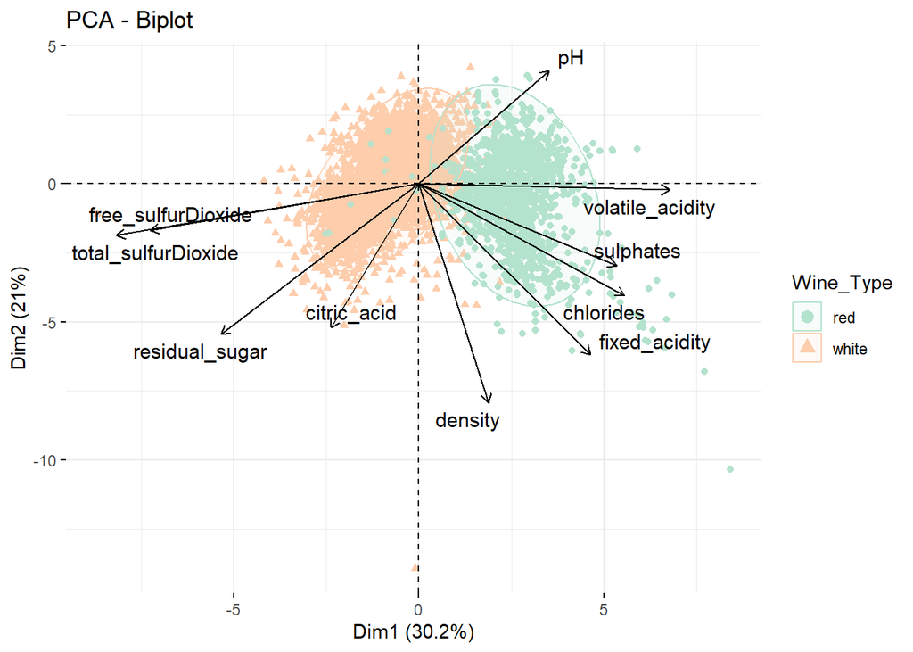

```r
fviz_pca_biplot(winePr, col.ind = wineQuality$wine_type, col="black",
                palette = "Pastel2", geom = "point", repel=TRUE,
                legend.title="Wine_Type", addEllipses = TRUE)
```

I observed that the eigenvalues of the first 3 components were >1. This explains a large part of the variance. So we can reduce our values from 10 to 3.When we examine the PCA values, the variance values decrease as expected.It was also observed that more than 50% of the variance could be explained by the variables PC1 and PC2.That’s why pc1 and pc2 components were used.The distribution of red and white wine with 2 components was clearly observed.Red wines cluster on the right, while white wines cluster on the left.When we examine the axes, we see that red wines are characterized by variables such as pH, volatile_acidity, sulphates.In white wine, on the other hand, variables such as citric_acid and residual_sugar were characterized.

## 6-) Apply Logistic Regression or Regression.

```r
set.seed(200)
trainIndex <- createDataPartition(wineQuality$wine_type, p = .8, list = FALSE)

trainSet <- wineQuality[trainIndex, ]
testSet <- wineQuality[-trainIndex, ]
```

```r
modelLogistic <- glm(wine_type~.,family="binomial", data=trainSet)
summary(modelLogistic)
```

```
##
## Call:
## glm(formula = wine_type ~ ., family = "binomial", data = trainSet)
##
## Deviance Residuals:
##     Min       1Q   Median       3Q      Max
## -5.9235   0.0003   0.0124   0.0464   4.3236
##
## Coefficients:
##                       Estimate Std. Error z value Pr(>|z|)
## (Intercept)          1.603e+03  2.080e+02   7.709 1.26e-14 ***
## fixed_acidity        6.121e-02  2.630e-01   0.233  0.81594
## volatile_acidity    -7.606e+00  1.279e+00  -5.947 2.72e-09 ***
## citric_acid          1.983e+00  1.357e+00   1.461  0.14390
## residual_sugar       9.857e-01  1.186e-01   8.309  < 2e-16 ***
## chlorides           -2.204e+01  4.421e+00  -4.987 6.15e-07 ***
## free_sulfurDioxide  -7.322e-02  1.703e-02  -4.301 1.70e-05 ***
## total_sulfurDioxide  5.701e-02  6.167e-03   9.246  < 2e-16 ***
## density             -1.594e+03  2.123e+02  -7.507 6.06e-14 ***
## pH                   6.733e-01  1.610e+00   0.418  0.67587
## sulphates           -3.718e+00  1.409e+00  -2.638  0.00835 **
## alcohol             -1.617e+00  3.095e-01  -5.225 1.74e-07 ***
## quality4            -1.395e+00  6.327e+00  -0.220  0.82552
## quality5            -3.937e+00  6.313e+00  -0.624  0.53280
## quality6            -3.505e+00  6.314e+00  -0.555  0.57886
## quality7            -3.362e+00  6.334e+00  -0.531  0.59559
## quality8            -2.253e+00  6.509e+00  -0.346  0.72927
## quality9             6.773e+00  9.688e+02   0.007  0.99442
## ---
## Signif. codes:  0 '***' 0.001 '**' 0.01 '*' 0.05 '.' 0.1 ' ' 1
##
## (Dispersion parameter for binomial family taken to be 1)
##
##     Null deviance: 5776.34  on 5170  degrees of freedom
## Residual deviance:  322.66  on 5153  degrees of freedom
## AIC: 358.66
##
## Number of Fisher Scoring iterations: 15
```

pH,fixed_acidity and citric_acid are variables that no significant effect. in our model.Our values such as alcohol, density, free_sulfurDioxide are significance according to the wine type.

```r
prediction <- predict(modelLogistic , testSet ,type="response")

confMatrixLog <- confusionMatrix(testSet$wine_type , prediction)
confMatrixLog
```

```
##   red white
## 0 314     1
## 1   4   973
```

```r
accur <- (confMatrixLog[1,1] + confMatrixLog[2,2])/ sum(confMatrixLog)
accur
```

```
## [1] 0.99613
```

314 red and 973 white wines were predicted correctly.The accuracy rate of the model we created is 0.99. Correct predictions were made in the test data set at a rate of 0.99.

```r
rocModelLog <- roc(testSet$wine_type ~ prediction) #control = negative class , case = positive class
```

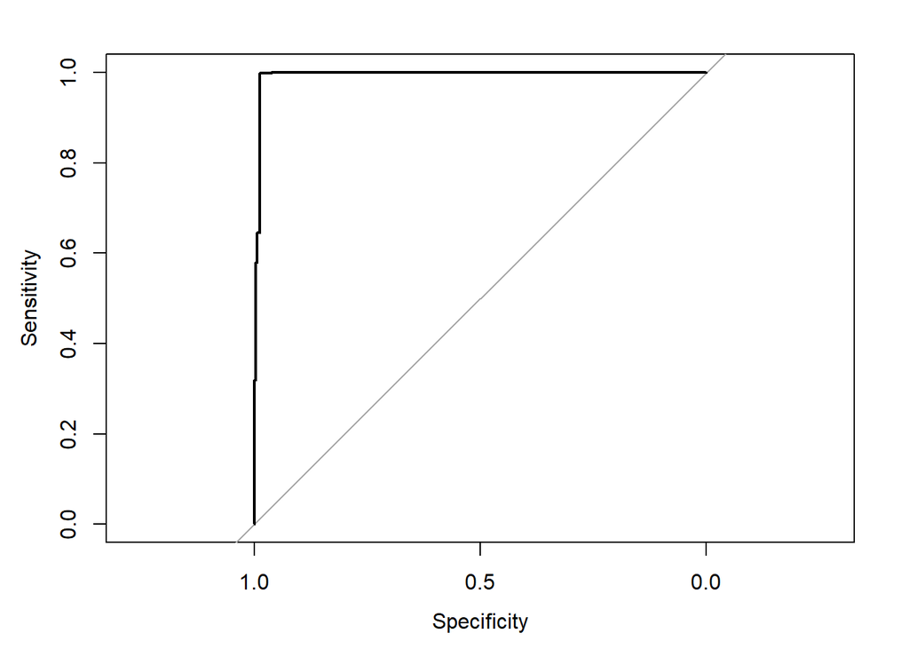

```r
plot(rocModelLog)
```

```r
rocModelLog
```

```
##
## Call:
## roc.formula(formula = testSet$wine_type ~ prediction)
##
## Data: prediction in 318 controls (testSet$wine_type red) < 974 cases (testSet$wine_type white).
## Area under the curve: 0.9943
```

The larger the area under the ROC curve, the better our model will be, and the higher the predictive power will be. The prediction performance is also excellent as the AUC value of the model we created is 0.99.

## 7-) Two clustering techniques.

#### a) Since there are categorical variables in our data and we have a large data set, we used K-means and DBSCAN clustering methods.

### 7.1.X-) K-means Clustering

```r
w_pr <- prcomp(wineQuality[,c(2:4)], center = TRUE, scale = TRUE)
summary(w_pr)
```

```
## Importance of components:
##                           PC1    PC2    PC3
## Standard deviation     1.1842 1.1031 0.6171
## Proportion of Variance 0.4675 0.4056 0.1269
## Cumulative Proportion  0.4675 0.8731 1.0000
```

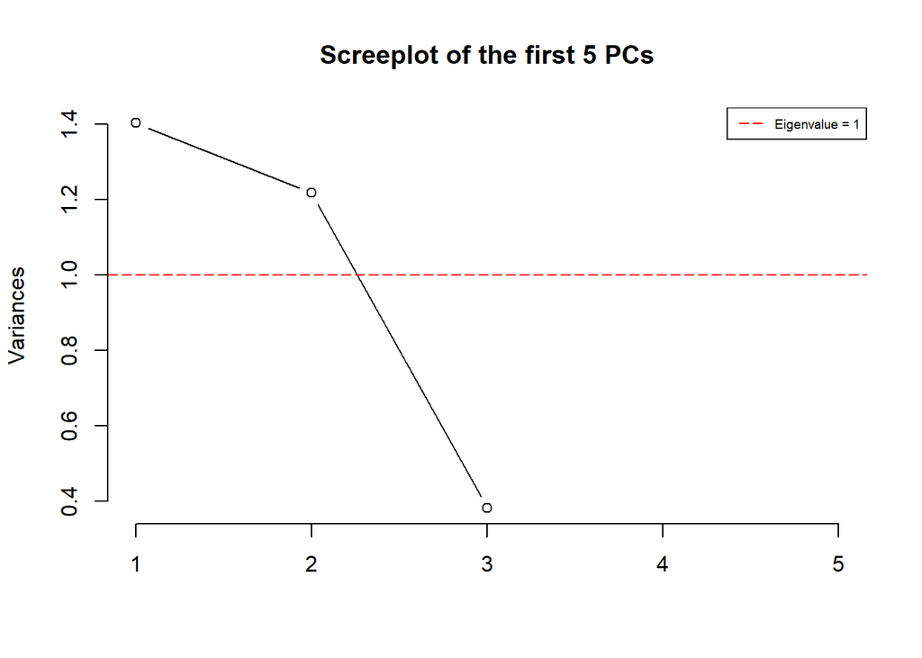

```r
screeplot(w_pr, type = "l", npcs = 5, main = "Screeplot of the first 5 PCs")
abline(h = 1, col="red", lty=5)
legend("topright", legend=c("Eigenvalue = 1"),
       col=c("red"), lty=5, cex=0.6)
```

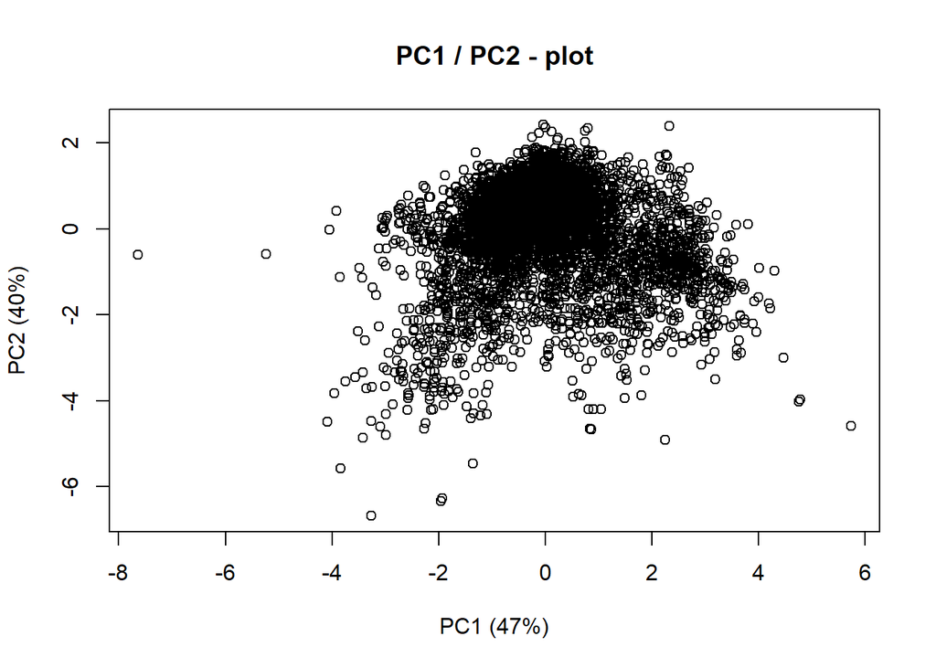

```r
plot(w_pr$x[,1],w_pr$x[,2], xlab="PC1 (47%)", ylab = "PC2 (40%)", main = "PC1 / PC2 - plot")
```

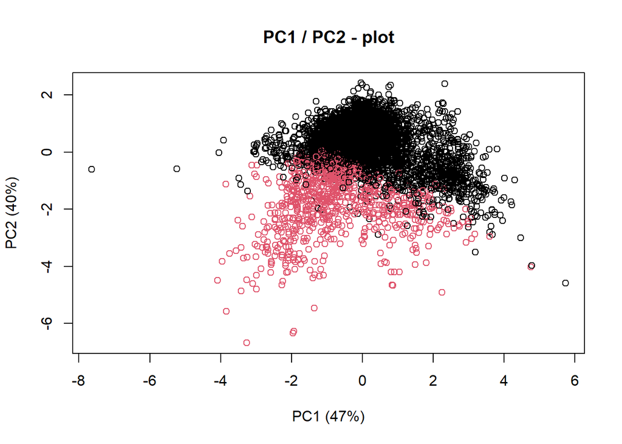

```r
set.seed(101)
km <- kmeans(wineQuality[,2:4], 2)
plot(w_pr$x[,1],w_pr$x[,2], xlab="PC1 (47%)",
     ylab = "PC2 (40%)",
     main = "PC1 / PC2 - plot",
     col=km$cluster)
```

Performs k-means clustering on the data in columns 2 through 4 of the wineQuality data frame and stores the results in the object km. The number 2 indicates that the function should create 2 clusters.

```r
km$centers
```

```
##   fixed_acidity volatile_acidity citric_acid
## 1      6.778960        0.3249178   0.3033524
## 2      9.474715        0.4150523   0.3979943
```

Finds the centers of columns 2 through 4 with km$centers.

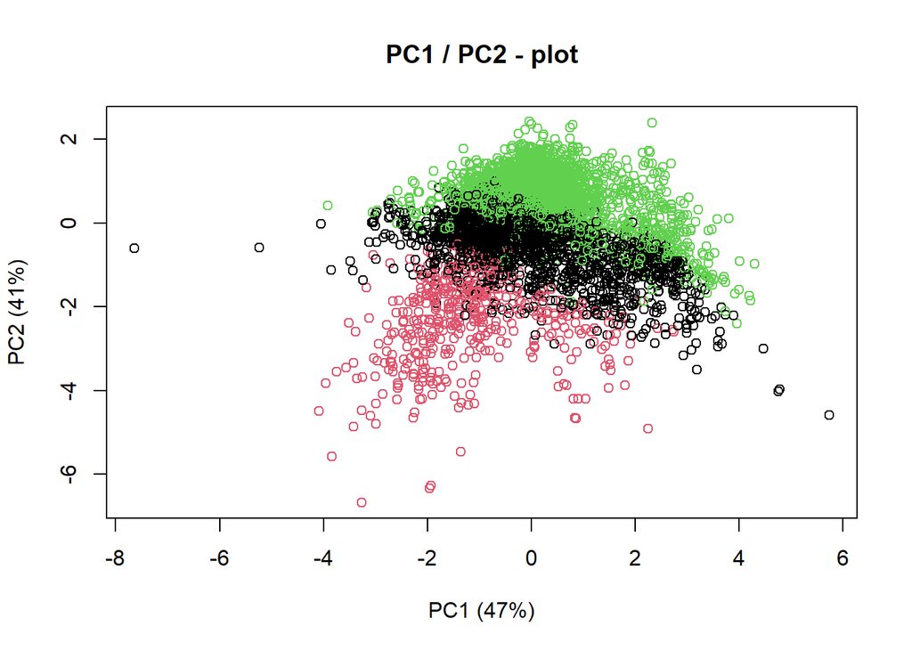

```r
set.seed(102)
km <- kmeans(wineQuality[,2:4], 3)
plot(w_pr$x[,1],w_pr$x[,2], xlab="PC1 (47%)",
     ylab = "PC2 (41%)",
     main = "PC1 / PC2 - plot",
     col=km$cluster)
```

```r
km$centers
```

```
##   fixed_acidity volatile_acidity citric_acid
## 1      7.646966        0.3551490   0.3233752
## 2     10.473633        0.4367090   0.4482422
## 3      6.313661        0.3101958   0.2937555
```

```r
table(km$cluster, wineQuality$wine_type)
```

```
##
##      red white
##   1  844  1941
##   2  441    71
##   3  308  2858
```

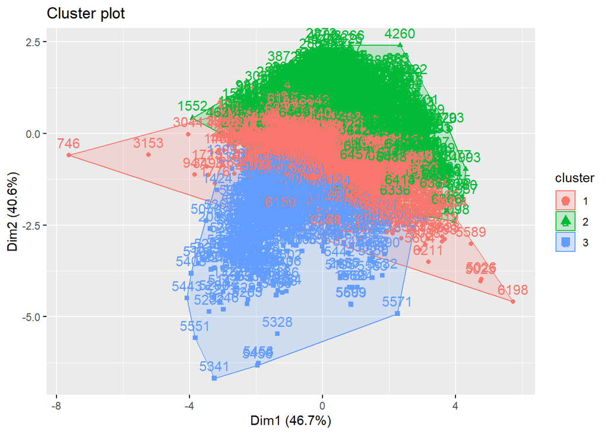

```r
km <- kmeans(wineQuality[,2:4], 3)
fviz_cluster(km, data = wineQuality[,2:4])
```

PCA was applied to the data and columns 2 and 4, which are numeric, were selected for column selection. The value of 3 was chosen for the k point and the center points were determined. These center points were then clustered using the kmeans method. The results of the kmeans clustering were then visualized.As seen in the figure, there were 3 clusters, namely blue, pink and green.

### 7.2-) DBSCAN Clustering

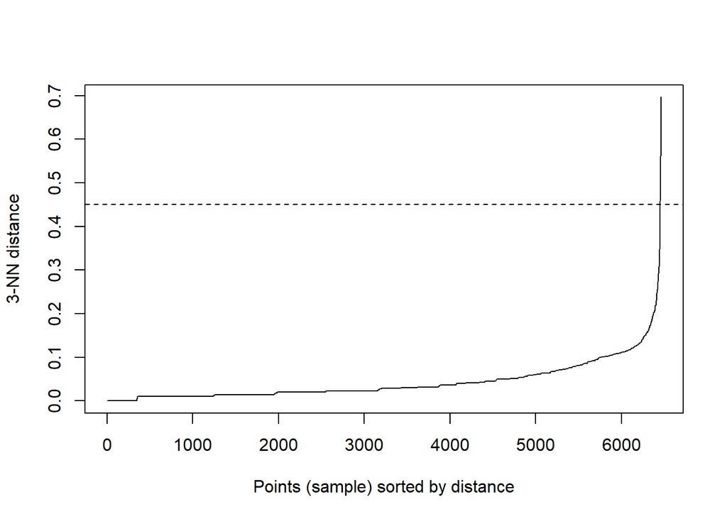

```r
kNNdistplot(wineQuality[2:4] , k =3)
abline(h=0.45,lty=2)
```

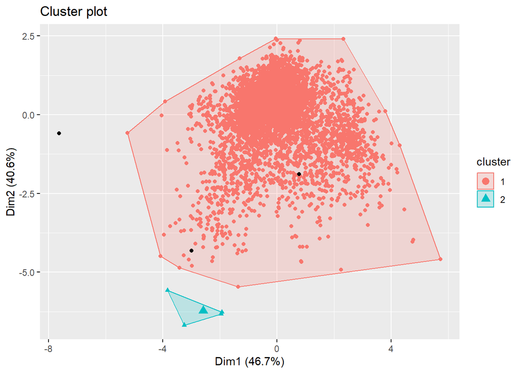

```r
f<- fpc::dbscan(wineQuality[2:4],eps=0.45,MinPts = 4)
d <- dbscan::dbscan(wineQuality[2:4],0.45,4)

fviz_cluster(f,wineQuality[2:4],geom="point")
```

#### b)Clustering was done by using 3 clusters in kmeans clustering and using 2 clusters in DBSCAN.When the two clusters were compared, it was observed that they were mostly concentrated in the middle.Outliers are clearly observed in both.

## X-) Use PCA Techniques

```r
wine_prodNA<-bind_cols(wineQuality[1],missForest::prodNA(wineQuality[-1],noNA=0.1))
wine_pca <- prcomp(wineQuality[,c(2:4,5,8,10)], center = TRUE,scale. = TRUE)
summary(wine_pca)
```

```
## Importance of components:
##                           PC1    PC2    PC3    PC4     PC5     PC6
## Standard deviation     1.4771 1.2372 0.9470 0.7920 0.65292 0.58056
## Proportion of Variance 0.3636 0.2551 0.1495 0.1046 0.07105 0.05617
## Cumulative Proportion  0.3636 0.6188 0.7682 0.8728 0.94383 1.00000
```

## 8-) Two classification techniques.

#### a) We used the Decision Tree and Logistic Regression classification to better explain our data and to explain the two first relationships between our features more meaningfully.

### 8.1-) Decision Tree Algorithm

```r
modelDecision <- rpart(formula= wine_type~., data=trainSet)
modelDecision
```

```
## n= 5171
##
## node), split, n, loss, yval, (yprob)
##       * denotes terminal node
##
##  1) root 5171 1275 white (0.246567395 0.753432605)
##    2) chlorides>=0.0615 1400  259 red (0.815000000 0.185000000)
##      4) total_sulfurDioxide< 113.5 1130   47 red (0.958407080 0.041592920)
##        8) density>=0.993215 1092   18 red (0.983516484 0.016483516) *
##        9) density< 0.993215 38    9 white (0.236842105 0.763157895) *
##      5) total_sulfurDioxide>=113.5 270   58 white (0.214814815 0.785185185)
##       10) fixed_acidity>=7.75 53   11 red (0.792452830 0.207547170) *
##       11) fixed_acidity< 7.75 217   16 white (0.073732719 0.926267281) *
##    3) chlorides< 0.0615 3771  134 white (0.035534341 0.964465659)
##      6) total_sulfurDioxide< 54 144   43 red (0.701388889 0.298611111)
##       12) chlorides>=0.0405 106   10 red (0.905660377 0.094339623) *
##       13) chlorides< 0.0405 38    5 white (0.131578947 0.868421053) *
##      7) total_sulfurDioxide>=54 3627   33 white (0.009098428 0.990901572) *
```

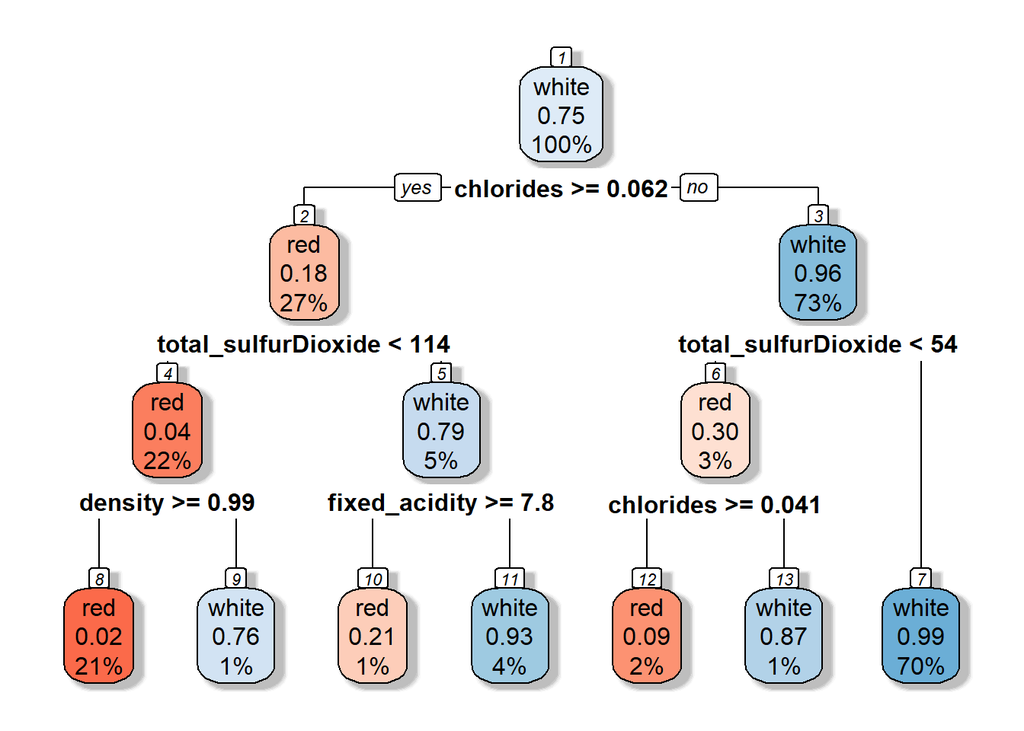

```r
rpart.plot(modelDecision, box.palette="RdBu", shadow.col="gray", nn=TRUE)
```

```r
probability_prediction <- predict(modelDecision,newdata = testSet,type = 'class')
head(probability_prediction,50)
```

```
##     3     4    10    16    20    24    35    36    43    46    47    52    54
## white white white white white white white white white white white white white
##    65    66    80    88    93    97   100   101   104   110   111   113   116
## white white white white white white white white white white white white   red
##   131   133   136   143   147   150   153   155   158   165   166   168   176
## white white white white white white white white white white white white white
##   179   185   190   193   195   196   199   232   242   244   256
## white white white white white white white white white white white
## Levels: red white
```

```r
confmatrixDecision <- table(testSet$wine_type,probability_prediction)
confmatrixDecision
```

```
##        probability_prediction
##         red white
##   red   294    24
##   white  10   964
```

```r
accurDecision <- (confmatrixDecision[1,1] + confmatrixDecision[2,2])/ sum(confmatrixDecision)
accurDecision
```

```
## [1] 0.9736842
```

Root node is chlorides. If the amount of chlorides is greater than 0.062, it enters the red wine class, if not, we can put it in the white wine class.Our accuracy value is almost 1. Therefore, 97% accuracy is achieved with the decision tree classification algorithm.

### Z.b-) Decision tree with balanced data.

```r
set.seed(200)
trainIndexx <- createDataPartition(dataset$wine_type, p = .8, list = FALSE)

trainSett <- dataset[trainIndexx, ]
testSett <- dataset[-trainIndexx, ]

modelBalanced <- rpart( wine_type~., data=dataset)
modelBalanced
```

```
## n= 9796
##
## node), split, n, loss, yval, (yprob)
##       * denotes terminal node
##
## 1) root 9796 4870 red (0.49714169 0.50285831)
##   2) chlorides< 0.0585 4818  391 white (0.91884599 0.08115401)
##     4) total_sulfurDioxide>=54 4496  123 white (0.97264235 0.02735765) *
##     5) total_sulfurDioxide< 54 322   54 red (0.16770186 0.83229814) *
##   3) chlorides>=0.0585 4978  443 red (0.08899156 0.91100844)
##     6) total_sulfurDioxide>=134.5 360   73 white (0.79722222 0.20277778) *
##     7) total_sulfurDioxide< 134.5 4618  156 red (0.03378086 0.96621914) *
```

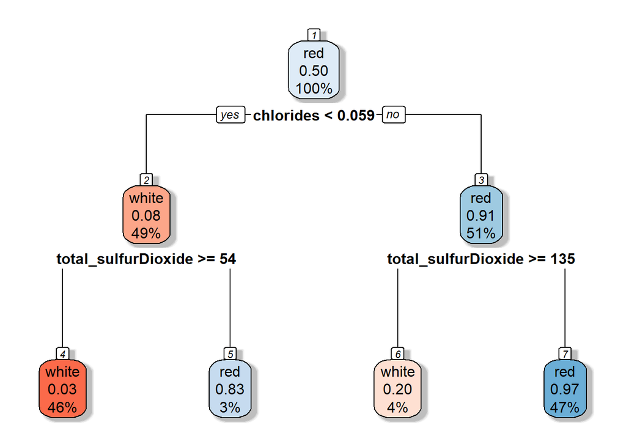

```r
rpart.plot(modelBalanced, box.palette="RdBu", shadow.col="gray", nn=TRUE)
```

```r
probability_predictionD <- predict(modelBalanced,newdata = testSett,type = 'class')
head(probability_predictionD,50)
```

```
##     3     7     9    19    33    34    36    48    49    50    51    56    65
## white white white white white   red white white white   red white white white
##    71    77    84    94    99   104   106   107   108   111   122   128   137
## white   red white white white white white white white   red white white white
##   148   149   151   159   160   172   178   182   183   186   189   193   202
## white white white white white   red white white white white white white white
##   211   212   213   231   234   237   238   247   248   251   260
## white white white white white white white white white white white
## Levels: white red
```

```r
confmatrixB <- table(testSett$wine_type,probability_predictionD)
confmatrixB
```

```
##        probability_predictionD
##         white red
##   white   930  44
##   red      39 946
```

```r
accurB <- (confmatrixB[1,1] + confmatrixB[2,2])/ sum(confmatrixB)
accurB
```

```
## [1] 0.9576314
```

We used the decision tree, which is one of the classification algorithms for the unbalanced and balance dataset. While the accuracy rate was 97% in our unbalanced dataset, this rate decreased to 95% in the balance dataset. The classification algorithm we created in the first version of our data was more stable and more prone to making correct decisions than the balanced dataset.

### 8.2-) Logistic Regression

Since we used logistic regression in question 6, we used the outputs of question 6 in this option.

```r
confMatrixLog
```

```
##   red white
## 0 314     1
## 1   4   973
```

```r
accur
```

```
## [1] 0.99613
```

## Y-) Missing Data Imputation

### Y.a-) About 10% of the dataset was deleted.

```r
wineMis <- prodNA(wineQuality, 0.10)
sum((is.na(wineMis)))
```

```
## [1] 8401
```

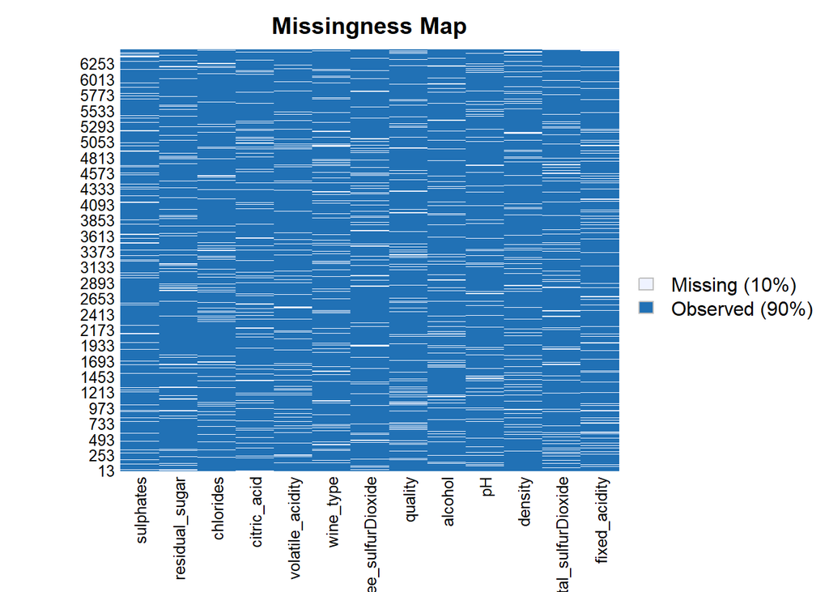

```r
missmap(wineMis)
```

First we checked the NA values in our data, there were 38 missing values in total. But we pretended that they didn’t exist because 38 missing values wouldn’t change the state of the model much. So we added the NA values first.We made approximately 10% of our data as NA values.

```r
write.csv(wineMis, "wineQualityLast.csv")
##wineQualityLast <- read_csv("C:/Users/Mary/Desktop/wineQualityLast.csv")
```

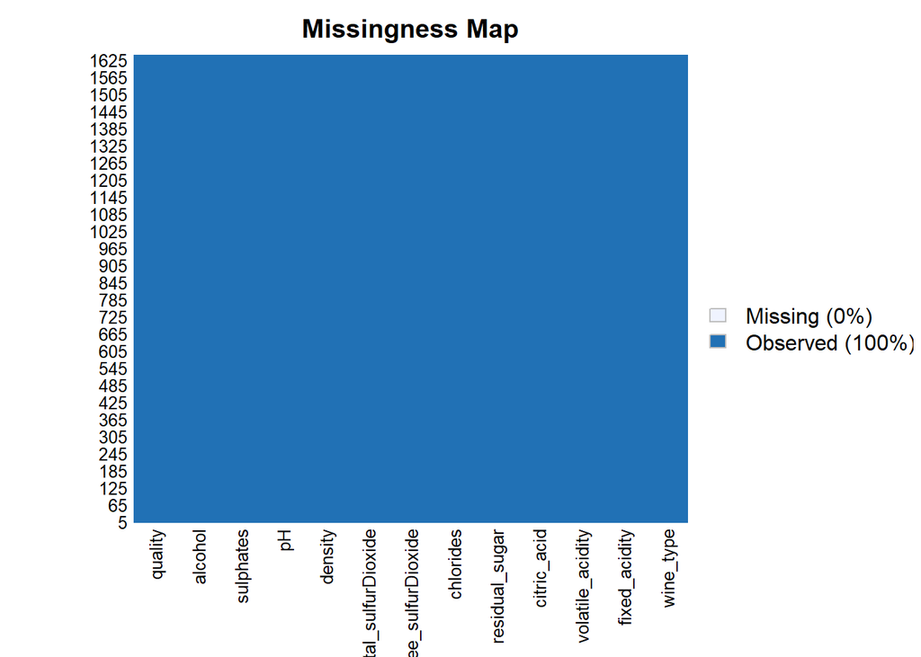

```r
wineMis<-na.omit(wineMis)
missmap(wineMis)
```

```r
set.seed(123)
wineMis$wine_type <- as.factor(wineMis$wine_type)
```

### Y.c-) Logistic Regression in data with missing values.

```r
sample<- createDataPartition(y= wineMis$wine_type,p=0.8,list = FALSE)

train_wineMis<- wineMis[sample,]
test_wineMis <- wineMis[-sample,]
```

```r
modelLogisticMis <- glm(wine_type~.,family="binomial", data=train_wineMis)
summary(modelLogisticMis)
```

```
##
## Call:
## glm(formula = wine_type ~ ., family = "binomial", data = train_wineMis)
##
## Deviance Residuals:
##     Min       1Q   Median       3Q      Max
## -5.3534   0.0002   0.0050   0.0219   1.0075
##
## Coefficients:
##                       Estimate Std. Error z value Pr(>|z|)
## (Intercept)          4.185e+03  8.397e+02   4.984 6.23e-07 ***
## fixed_acidity        2.467e+00  6.944e-01   3.553 0.000381 ***
## volatile_acidity    -8.696e+00  2.876e+00  -3.023 0.002502 **
## citric_acid          3.153e+00  3.633e+00   0.868 0.385400
## residual_sugar       1.945e+00  4.165e-01   4.669 3.03e-06 ***
## chlorides           -1.177e+01  9.930e+00  -1.185 0.236051
## free_sulfurDioxide  -1.110e-01  3.760e-02  -2.952 0.003162 **
## total_sulfurDioxide  5.168e-02  1.289e-02   4.008 6.12e-05 ***
## density             -4.226e+03  8.503e+02  -4.969 6.72e-07 ***
## pH                   1.718e+01  4.564e+00   3.763 0.000168 ***
## sulphates            1.174e+00  3.496e+00   0.336 0.737024
## alcohol             -4.998e+00  1.150e+00  -4.347 1.38e-05 ***
## quality4            -5.956e+00  9.683e+00  -0.615 0.538492
## quality5            -8.946e+00  9.690e+00  -0.923 0.355889
## quality6            -7.675e+00  9.666e+00  -0.794 0.427175
## quality7            -9.522e+00  9.714e+00  -0.980 0.326964
## quality8            -6.272e+00  1.233e+01  -0.509 0.610932
## quality9            -1.684e+00  1.489e+03  -0.001 0.999097
## ---
## Signif. codes:  0 '***' 0.001 '**' 0.01 '*' 0.05 '.' 0.1 ' ' 1
##
## (Dispersion parameter for binomial family taken to be 1)
##
##     Null deviance: 1429.974  on 1311  degrees of freedom
## Residual deviance:   64.006  on 1294  degrees of freedom
## AIC: 100.01
##
## Number of Fisher Scoring iterations: 15
```

```r
predictionMis <- predict(modelLogisticMis , test_wineMis ,type="response")

confMatrixLogMis <- confusionMatrix(test_wineMis$wine_type , predictionMis)
confMatrixLogMis
```

```
##   red white
## 0  74     0
## 1   3   251
```

```r
accurMis <- (confMatrixLogMis[1,1] + confMatrixLogMis[2,2])/ sum(confMatrixLogMis)
accurMis
```

```
## [1] 0.9908537
```

```r
accur
```

```
## [1] 0.99613
```